# Week 8

MACS 30405: Exploring Cultural Space  
University of Chicago

## Reflection on HW Exercises

- What dimensional structures did you find in your data?
- When is dimensional thinking/analysis useful?

# DW-Nominate

- What does dimensional reduction on congressional role calls capture or not capture?

## Baron et al. (2018)

- Information-theory-based measurement of ideology during the French Revolution
  - Novelty: the amount of surprise in a document with respect to prior discourses
  - Transience: the amount of surprise in a document with respect to posterior discourses
  - Resonance: Novelty - Transience

## Let’s talk about their measurement.

- They measure ideology not in terms of the speeches’ internal content but in terms of their relationships with other speeches.
  - The left tries to inject new information into the space.
  - The right tries to preserve information in the space.

## The emergence of comittees as an endogeneous process

- In the first epoch, disruptive in-debate committee speeches generate more resonance.
- In the second epoch, committees stabilize and new items oftentimes are accepted without discussion.

## What does their finding mean?

> By quantifying the flow of word patterns between times and speakers, we see not just the traces of a conscious battle of ideas but also—more important and more clearly—the contours of a new rhetorical space. This latter was neither intentionally produced nor was it the exclusive property of any one political group. New word patterns from the left resonated, but so too did old ones from the right. Political actors did not just take different ideological positions, but played different roles in the propagation of patterns. And together, in both cooperation and competition, they invented new mechanisms for the collective management of information.

# Two Threads from Our Previous Discussions

## Thread 1: Ideology as not just “elective affinity of ideas” stemming from bottom up but also ideas aligned and constrained by the elites

## Thread 2: Dimensional biases in language

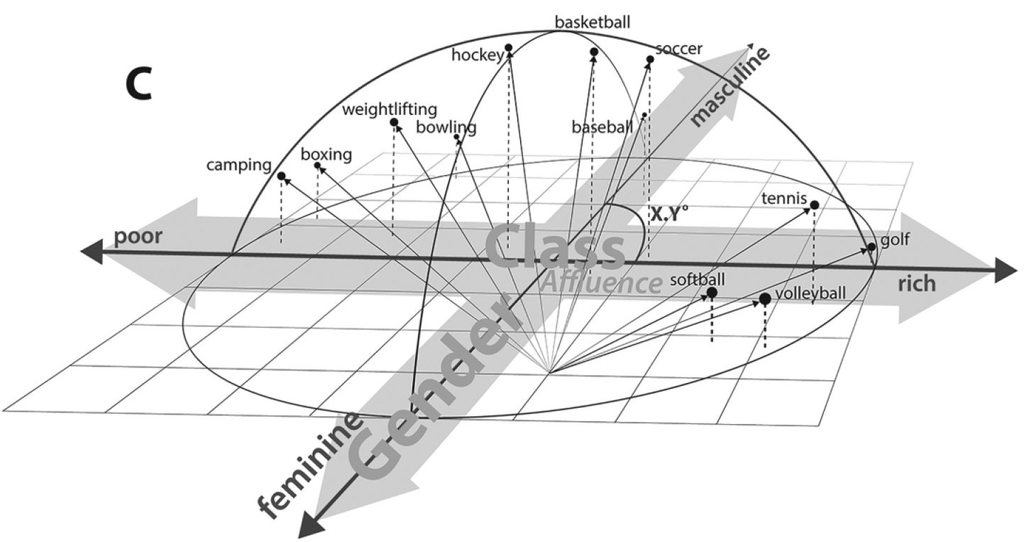

## Questions

- To what extent are the dimensional biases manifestation of ideology?
  - Are they biased in people’s subjective understanding or
  - people’s everyday practices?
- What is the appropriate level of analysis for discourse analysis?
  - Individuals?
  - Words?